# Test of significance for one population mean

Mike Hitchman

10/20/2021

### The Scene

Suppose we want to test whether a population mean is equal to the value $\mu_0$,

$$H_0: \mu = \mu_0$$

against one of these three alternative hypotheses:

- $H_a: \mu > \mu_0$ (one-sided, `greater` than $\mu_0$)
- $H_a: \mu < \mu_0$ (one-sided, `less` than $\mu_0$)
- $H_a: \mu \neq \mu_0$ (`two.sided`)

We assume the population standard deviation $\sigma$ is unknown so we use a t-distribution in our test.

### The Example

**The question**

Google says Woolly Bear caterpillars generally have length between 39 and 51 millimeters, suggesting an average of around 45 millimeters. Based on the independent sample of woolly bear caterpillars found in my neck of the woods, do I have significant evidence that the local woolly bear population has mean length different than 45 millimeters?

```r
wb = c(52.0, 48.9, 47.3, 47.3, 48.6, 48.8, 42.8, 44.3, 46.7, 46.4, 47.5, 51.4, 49.0, 47.7, 48.5, 48.5, 45.8, 49.3, 48.1, 46.5)
```

**The hypotheses**

$$\begin{cases}
H_o: \mu = 45 \\
H_a: \mu \neq 45
\end{cases}$$

To conduct the test we follow the Prepare-Check-Calculate-Conclude procedure:

**Prepare** for the significance test:

```r
n = length(wb)
xbar = mean(wb)
s = sd(wb)
```

$n$ = 20; $\bar{x}$ = 47.77; $s$ = 2.1138889

**Check.** Measurements in an animal or plant population are often normally distributed, so barring extreme values (which we can check with a histogram) the t-distribution is a reasonable model.

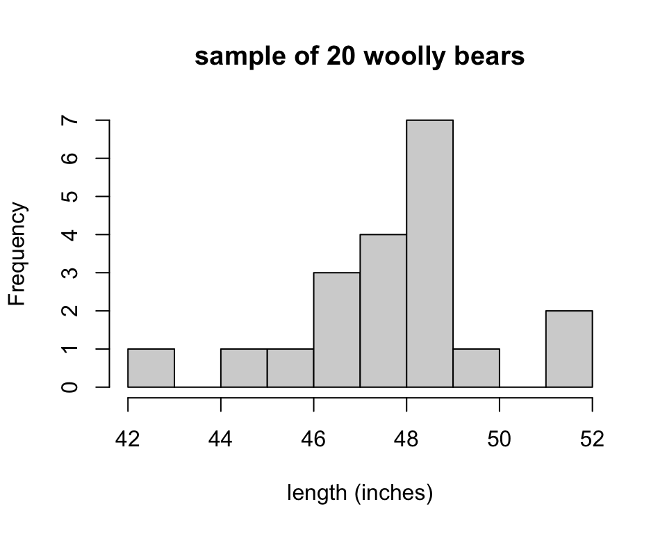

```r
hist(wb,breaks=12,main=paste("sample of",n,"woolly bears"),xlab="length (inches)")
```

**Calculate**

We find the test statistic from our data, which is a t-score in this case, and the p-value associated to this test statistic. We can ask RStudio to do the calculations, and note that the test statistic is given by the formula
$$t = \frac{\bar{x}-\mu_0}{s/\sqrt{n}},$$
where $\mu_0$ is the value of the mean in the null hypothesis.

```r
## Conducting a test of significance for one mean

# Significance level
alpha=.05

# Value of mean under the null hypothesis
mu_0 = 45

## Data
wb = c(52.0, 48.9, 47.3, 47.3, 48.6, 48.8, 42.8, 44.3, 46.7, 46.4, 47.5, 51.4, 49.0, 47.7, 48.5, 48.5, 45.8, 49.3, 48.1, 46.5)
n=length(wb) #sample size
xbar=mean(wb) #sample mean
s = sd(wb) #sample standard deviation

# Standard error
SE = s/sqrt(n)

# Test statistic
t = (xbar-mu_0)/SE

# Degrees of Freedom
df = n-1

# p-Value
p_val.lt = pt(t,df) # this is the p-value if H_a: mu < mu_0
p_val.gt = 1 - pt(t,df) # this is the p-value if H_a: mu > mu_0
p_val.neq = 2*(1-pt(abs(t),df)) # this is the p-value if H_a: mu not equal to mu_0

## Generating a Nice Output:
cat(paste0("Null hypthosis: mu = ",mu_0,"\n",
           "sample mean = ",round(xbar,3),"\n",
           "test statistic, t = ",round(t,3),"\n",
           "degrees of freedom, df = ",df,"\n",
           "p-value for H_a: mu < ",mu_0,": ",p_val.lt,"\n",
           "p-value for H_a: mu > ",mu_0,": ",p_val.gt,"\n",
           "p-value for H_a: mu not equal to ",mu_0,": ",p_val.neq,"\n"))
```

```
## Null hypthosis: mu = 45
## sample mean = 47.77
## test statistic, t = 5.86
## degrees of freedom, df = 19
## p-value for H_a: mu < 45: 0.9999939519353
## p-value for H_a: mu > 45: 6.04806470005936e-06
## p-value for H_a: mu not equal to 45: 1.20961294001187e-05
```

In our example we used $H_a: \mu \neq 45$, so we obtain this p-value:

```r
(p_value=p_val.neq)
```

```
## [1] 1.209613e-05
```

**Conclude**

Comparing this p-value to the significance level we see:

```r
p_value < alpha
```

```
## [1] TRUE
```

TRUE! Since the p-value is smaller than alpha, we reject H_0 in favor of H_a at the significance level 0.05. We have sufficient evidence to conclude that the average length of woolly bear caterpillars in our neck of the woods is different than 45 millimeters.

### t.test()

The `t.test()` function in R conducts this test of significance. If you type t.test in the RStudio help search box you can get information about options. The following code reproduces the test of significance we just ran through. Essentially we input the data vector, the value of the mean under the null hypothesis, and the nature of our alternative hypothesis.

```r
t.test(wb, mu=45, alternative="two.sided")
```

```
##
##  One Sample t-test
##
## data:  wb
## t = 5.8602, df = 19, p-value = 1.21e-05
## alternative hypothesis: true mean is not equal to 45
## 95 percent confidence interval:
##  46.78067 48.75933
## sample estimates:
## mean of x
##     47.77
```